# Ford GoBike Analysis 2017 - Aug 2020

#### by Byron Thompson

## Investigation Overview

> The goal of this presentation is to provide the reader with a comprehensive analysis of the GoBike data that will highlight the success, or not, of the Ford GoBike scheme and to highlight the populous trends when it comes to usuage during the year and who the bikes are used by.

> Upon answering the above questions I will then conclude with what I think the data means as an avid cycle commuter myself.

## Dataset Overview

> The data that I will be investigating is taken from the Ford GoBike System Data site which contains record on millions of bike hires from 2017 to 2020. For the purposes of this report that data that I analysed was from 2017 - Aug 2020.

### Hire hours

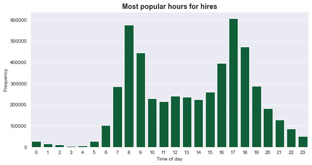

```python
# returns most popular count for hours of day
plt.rcParams['figure.figsize'] = 10, 5
base_color = sns.color_palette('YlGn_r')[0]
sns.set_style('darkgrid')

sns.countplot(data=df_Ford_Go_Bike_2017_2020_Master_CLEAN_v5, x='start_hour', color=base_color);
plt.title('Most popular hours for hires', weight='bold').set_fontsize('14')
plt.xlabel('Time of day');
plt.ylabel('Frequency');
```

### Hires over a week

Below is an illustration of bike hires over a week.

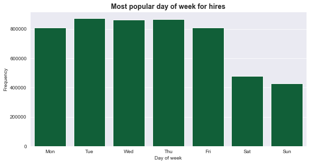

```python
# Most popular day of the week for hiring bikes
plt.rcParams['figure.figsize'] = 10, 5
base_color = sns.color_palette('YlGn_r')[0]
sns.set_style('darkgrid')

sns.countplot(data=df_Ford_Go_Bike_2017_2020_Master_CLEAN_v5, x='start_day_of_week', color=base_color);
plt.title('Most popular day of week for hires', weight='bold').set_fontsize('14')
plt.xlabel('Day of week');
plt.ylabel('Frequency');
```

### Hires over a month

Below is an illustration of bike hires over a month.

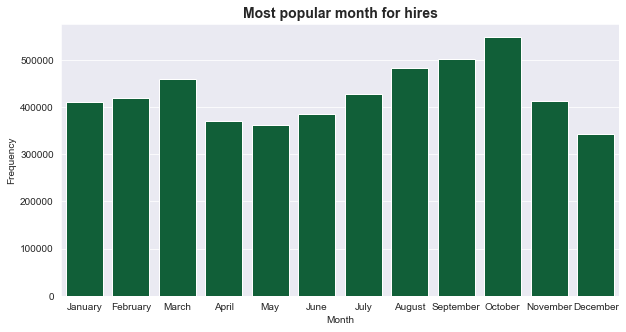

```python
# Breakdown by month
plt.rcParams['figure.figsize'] = 10, 5
base_color = sns.color_palette('YlGn_r')[0]
sns.set_style('darkgrid')

sns.countplot(data=df_Ford_Go_Bike_2017_2020_Master_CLEAN_v5, x='start_month', color=base_color);
plt.title('Most popular month for hires', weight='bold').set_fontsize('14')
plt.xlabel('Month');
plt.ylabel('Frequency');
```

### Hires over 4 years (2017 - Aug 2020)

Below is an illustration of bike hires over a 4 year period.

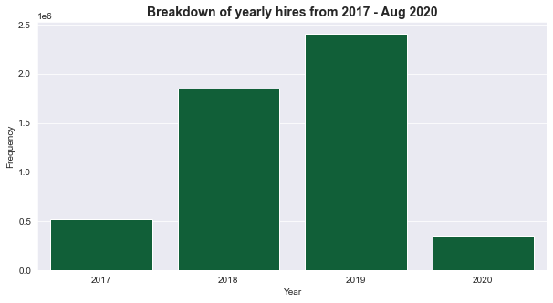

```python
# Breakdown by year
plt.rcParams['figure.figsize'] = 10, 5
base_color = sns.color_palette('YlGn_r')[0]
sns.set_style('darkgrid')

sns.countplot(data=df_Ford_Go_Bike_2017_2020_Master_CLEAN_v5, x='year', color=base_color);
plt.title('Breakdown of yearly hires from 2017 - Aug 2020', weight='bold').set_fontsize('14')
plt.xlabel('Year');
plt.ylabel('Frequency');
```

There has been a steady increase in bike hires from 2017 onwards rising to a peak of over 2.4m hires in 2019. ALthough it would appear that 2020 is going to be less than 2019 even taking into account that the data is derived upto August with only 4 months to go until the end of the year.

### User Types

Below is an illustration of the allocation split between Subscribers and Customers who hire bikes.

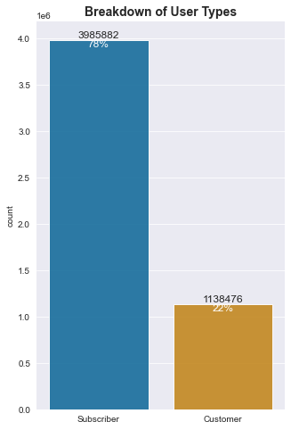

```python
# Breakdown of user types

# Plotting
fig, ax = plt.subplots(figsize = (5,8))

sns.countplot(x = "user_type", data = df_Ford_Go_Bike_2017_2020_Master_CLEAN_v5,
              order = df_Ford_Go_Bike_2017_2020_Master_CLEAN_v5['user_type'].value_counts().index,
              palette = sns.color_palette('colorblind'), alpha=0.9)

# Percentage for each age-group
perc_list = []

# Calculate % for 2 user types
type_sum = df_Ford_Go_Bike_2017_2020_Master_CLEAN_v5['user_type'].value_counts().to_list()
total_sum = df_Ford_Go_Bike_2017_2020_Master_CLEAN_v5.shape[0]

# arrange the % list in same as annotate loop order
for i in range(0,len(type_sum)):
    percent = int(round(100 * type_sum[i] / total_sum))
    perc_list.append(percent)

# Annotate
i=0
for p in ax.patches:
    ax.annotate('{:.0f}'.format(p.get_height()),
                (p.get_x()+p.get_width()/2, p.get_height()),
                ha="center", va="bottom", size=12)
    ax.annotate('{:.0f}%'.format(perc_list[i]),
                (p.get_x()+p.get_width()/2, p.get_height()),
                ha="center", va="top", color='white', size=12)
    i+=1

# formatting
plt.title('Breakdown of User Types', weight='bold', size=14)
sns.despine(fig, left = True)
plt.xlabel("");
```

In total subscribers hire nearly four times as many bikes as customers with 78% of the total bike hires.

### Distance by User Type

Below is an illustration of distances traveled by each type of user

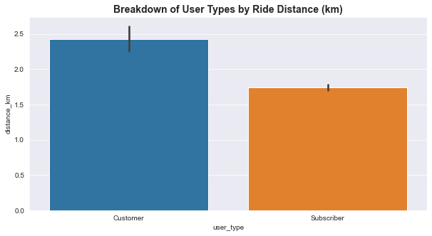

```python
# returns breakdown of user type by distance
sns.barplot(x='user_type',  y='distance_km', data=df_Ford_Go_Bike_2017_2020_Master_CLEAN_v5)
plt.title('Breakdown of User Types by Ride Distance (km)', weight='bold', size=14);
```

Although there are far more subscribers hiring bikes when it comes to distance customers travel a further distance then subscribers. In total they travel an average of just under 2.5 km which is more than than average 1.9 km total average.

### Duration by User Type

Below is an illustration of bike hire duration by each type of user

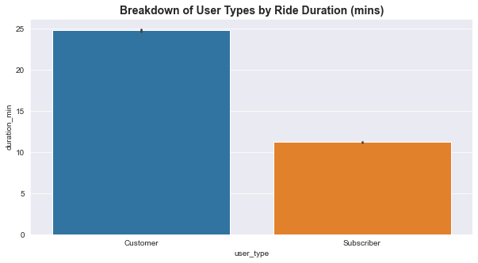

```python
# returns breakdown of user type by duration
sns.barplot(x='user_type',  y='duration_min', data=df_Ford_Go_Bike_2017_2020_Master_CLEAN_v5)
plt.title('Breakdown of User Types by Ride Duration (mins)', weight='bold', size=14);
```

When it comes to the duration of rides it appears that customers spend twice as long on their rides than subscribers, this is not a surprise majority of subscribers will be commuters whereas customers are more leisure riders and go out for longer.

### Monthly Number of Bike Hires by User Type

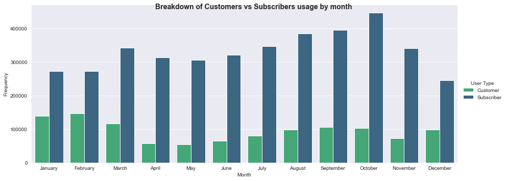

```python
# returns breakdown of customers vs subsribers by month
g = sns.catplot(data=df_Ford_Go_Bike_2017_2020_Master_CLEAN_v5, x='start_month', hue='user_type', kind='count',aspect=20.7/8.27, color=base_color,
                palette='viridis_r')

g.set_axis_labels('Month', 'Frequency')
g._legend.set_title('User Type')
g.fig.suptitle('Breakdown of Customers vs Subscribers usage by month', fontsize=14, fontweight='bold');
```

Subscribers have by far the greater amount of usage throughout the year with October seeing the most hires for subscribers whereas February saw the highest for customers.

### Conclusion

As a daily bike commuter (owner, not hirer) this project was interesting for me as I have seen over the years more & more commuters using the London equivalent of the Ford GoBike hire scheme. The numbers re very impressive and from a climate change perspective it is very encouraging that so many people be subscribers or customers are using bicycles to travel.

The analysis shows that year-on-year the use of rental bikes is increasing although 2020 doesn't seem to be on the same upward trend. It's clear that the majority of subscribers are work commuters during the week as the highest bike hires take place in the morning and evening.

I would say that the Ford GoBike system has been an unequivocal success and has benefits to not only the users (healthy exercise) but also to the city of San Francisco in reduced traffic and congestion.

Finally, it would have been a much more varied and detailed analysis if I was able to derive more details from the data such as age of users and gender.